# 06. Test7 combined decontam and cross-method validation

Test7 decontamination sensitivity analysis

2026-10-02

# 1 1. Analysis question

This report adds the previously missing `decontam` `method = "combined"` analysis to Test7 and then compares the prespecified pooled combined result at threshold 0.5 with SCRuB and MicrobIEM. It does not select or optimize a threshold from the same data.

The analysis follows the established Test7 definitions:

- biological samples: samples that are neither negative nor positive controls;
- negative controls: Prep controls plus Air Swabs;
- positive controls: excluded from contaminant learning and from the primary cross-method comparison;
- concentration: `DNA_ng_uL`, with zero replaced by half the smallest positive concentration, exactly as in scripts 02–04;
- thresholds: 0.01, 0.05, and 0.1–0.9 by 0.1;
- batch settings: pooled and `Cycle`-aware.

SCRuB produces sample-specific corrected counts, whereas decontam and MicrobIEM produce binary ASV calls. Therefore continuous read-removal agreement is the primary SCRuB comparison. SCRuB binary summaries at 10%, 50%, and 90% removal are descriptive sensitivity analyses only.

# 2 2. Packages and paths

```r
library(phyloseq)
library(decontam)
library(SCRuB)
library(dplyr)
library(tidyr)
library(ggplot2)
library(readr)

package_dir <- normalizePath(
  file.path("..", "..", "decontamSensitivity"),
  winslash = "/", mustWork = TRUE
)
devtools::load_all(package_dir, quiet = TRUE)

input_path <- file.path("Phyloseq", "phy_F270R210_260921.rds")
output_dir <- file.path("Results", "Test7", "06_combined_cross_method_validation")
dir.create(output_dir, recursive = TRUE, showWarnings = FALSE)

microbiem_source <- paste0(
  "D:/KSY/Project/10.AT_multicenter/Results/260909_reanalysis/",
  "tmp/tool_sources/MicrobIEM/MicrobIEM_decontamination.R"
)

thresholds <- c(0.01, 0.05, seq(0.1, 0.9, by = 0.1))
methods <- c("prevalence", "frequency", "combined")
method_colors <- c(
  Prevalence = "#1B9E77", Frequency = "#D95F02", Combined = "#7570B3",
  `SCRuB non-spatial` = "#E7298A", `SCRuB spatial` = "#E6AB02",
  MicrobIEM = "#66A61E"
)
theme_set(theme_bw(base_size = 11))
```

# 3 3. Input validation and exact sample scope

```r
stopifnot(file.exists(input_path), file.exists(microbiem_source))
phy_input <- readRDS(input_path)
stopifnot(inherits(phy_input, "phyloseq"))

meta_original <- data.frame(sample_data(phy_input), check.names = FALSE)
required_columns <- c(
  "control_type", "Sample_Control", "Subject", "Cycle", "DNA_ng_uL"
)
if (!all(required_columns %in% colnames(meta_original))) {
  stop("Missing metadata: ", paste(setdiff(required_columns, colnames(meta_original)), collapse = ", "))
}

sample_info <- meta_original |>
  tibble::rownames_to_column("sample_id") |>
  mutate(
    Cycle = sub("\\.0$", "", as.character(Cycle)),
    well_no = as.integer(No),
    plate_row_no = (well_no - 1) %% 8 + 1,
    plate_col = (well_no - 1) %/% 8 + 1,
    plate_row = LETTERS[plate_row_no],
    well = paste0(plate_row, plate_col),
    is_prep_control = !is.na(control_type) & control_type == "Prep control",
    is_air_swab = !is.na(control_type) & control_type == "Air Swab",
    is_positive_control = !is.na(Sample_Control) & Sample_Control == "PC",
    is_negative_control = is_prep_control | is_air_swab,
    is_biological = !is_negative_control & !is_positive_control,
    concentration_raw = suppressWarnings(as.numeric(DNA_ng_uL))
  )

if (anyNA(sample_info$concentration_raw) || any(sample_info$concentration_raw < 0)) {
  stop("DNA_ng_uL must be complete, numeric, and non-negative.")
}
smallest_positive <- min(sample_info$concentration_raw[sample_info$concentration_raw > 0])
zero_replacement <- smallest_positive / 2
sample_info <- sample_info |>
  mutate(
    decontam_concentration = if_else(
      concentration_raw == 0, zero_replacement, concentration_raw
    ),
    sample_role = case_when(
      is_prep_control ~ "Prep control",
      is_air_swab ~ "Air Swab",
      is_positive_control ~ "Positive control",
      TRUE ~ "Biological sample"
    ),
    decontam_group = if_else(is_negative_control, "negative_control", "biological")
  )

scope_ids <- sample_info$sample_id[
  sample_info$is_biological | sample_info$is_negative_control
]
ps_scope <- prune_samples(scope_ids, phy_input)
ps_scope <- prune_taxa(taxa_sums(ps_scope) > 0, ps_scope)

scope_info <- sample_info |>
  filter(sample_id %in% scope_ids) |>
  arrange(match(sample_id, sample_names(ps_scope)))
scope_meta <- meta_original[scope_info$sample_id, , drop = FALSE]
scope_meta$Cycle <- scope_info$Cycle
scope_meta$is_prep_control <- scope_info$is_prep_control
scope_meta$is_air_swab <- scope_info$is_air_swab
scope_meta$is_negative_control <- scope_info$is_negative_control
scope_meta$is_biological <- scope_info$is_biological
scope_meta$decontam_group <- scope_info$decontam_group
scope_meta$concentration_raw <- scope_info$concentration_raw
scope_meta$decontam_concentration <- scope_info$decontam_concentration
rownames(scope_meta) <- scope_info$sample_id
sample_data(ps_scope) <- sample_data(scope_meta)

count_matrix <- as(otu_table(ps_scope), "matrix")
if (taxa_are_rows(ps_scope)) count_matrix <- t(count_matrix)
count_matrix <- count_matrix[sample_names(ps_scope), taxa_names(ps_scope), drop = FALSE]

biological_ids <- scope_info$sample_id[scope_info$is_biological]
prep_ids <- scope_info$sample_id[scope_info$is_prep_control]
air_ids <- scope_info$sample_id[scope_info$is_air_swab]
control_ids <- c(prep_ids, air_ids)
biological_counts <- count_matrix[biological_ids, , drop = FALSE]

input_summary <- data.frame(
  item = c(
    "Input samples", "Analysis samples", "Biological samples", "Prep controls",
    "Air Swabs", "Positive controls excluded", "ASVs after scope pruning",
    "Zero concentrations replaced", "Replacement concentration (ng/uL)"
  ),
  value = c(
    nsamples(phy_input), nsamples(ps_scope), length(biological_ids),
    length(prep_ids), length(air_ids), sum(sample_info$is_positive_control),
    ntaxa(ps_scope), sum(scope_info$concentration_raw == 0), zero_replacement
  )
)
write_csv(input_summary, file.path(output_dir, "06_01_input_summary.csv"))
write_csv(
  scope_info |> select(sample_id, sample_role, Cycle, well_no, well,
                       plate_row_no, plate_col, DNA_ng_uL,
                       concentration_raw, decontam_concentration),
  file.path(output_dir, "06_02_sample_assignments.csv")
)
knitr::kable(input_summary, digits = 4, format.args = list(big.mark = ","))
```

| item | value |
| --- | --- |
| Input samples | 73.0000 |
| Analysis samples | 69.0000 |
| Biological samples | 55.0000 |
| Prep controls | 9.0000 |
| Air Swabs | 5.0000 |
| Positive controls excluded | 4.0000 |
| ASVs after scope pruning | 4,571.0000 |
| Zero concentrations replaced | 3.0000 |
| Replacement concentration (ng/uL) | 0.0655 |

```r
scope_balance <- scope_info |>
  count(Cycle, sample_role, name = "n_samples") |>
  complete(Cycle, sample_role, fill = list(n_samples = 0))
write_csv(scope_balance, file.path(output_dir, "06_03_cycle_sample_balance.csv"))
knitr::kable(scope_balance)
```

| Cycle | sample_role | n_samples |
| --- | --- | --- |
| 1 | Air Swab | 2 |
| 1 | Biological sample | 19 |
| 1 | Prep control | 3 |
| 2 | Air Swab | 2 |
| 2 | Biological sample | 19 |
| 2 | Prep control | 3 |
| 3 | Air Swab | 1 |
| 3 | Biological sample | 17 |
| 3 | Prep control | 3 |

# 4 4. decontam prevalence, frequency, and combined sweep

The three methods are rerun on the identical ASV table and controls. The Cycle-aware analysis passes `Cycle` directly to decontam as the batch variable; it is not a separate per-Cycle post hoc union.

```r
cache_path <- file.path(output_dir, "06_decontam_sweep_cache.rds")
cache_config <- list(
  input_md5 = unname(tools::md5sum(input_path)), thresholds = thresholds,
  methods = methods, package_version = as.character(packageVersion("decontamSensitivity"))
)

use_cache <- FALSE
if (file.exists(cache_path) && !isTRUE(params$force_recompute)) {
  cached <- readRDS(cache_path)
  use_cache <- identical(cached$config, cache_config)
}

if (use_cache) {
  decontam_runs <- cached$runs
} else {
  decontam_runs <- list()
  for (method_name in methods) {
    for (batch_mode in c("pooled", "cycle_aware")) {
      args <- list(
        ps = ps_scope,
        control_column = "decontam_group",
        control_label = "negative_control",
        thresholds = thresholds,
        method = method_name
      )
      if (method_name %in% c("frequency", "combined")) {
        args$concentration_column <- "decontam_concentration"
      }
      if (batch_mode == "cycle_aware") args$batch <- "Cycle"
      run_id <- paste(method_name, batch_mode, sep = "__")
      decontam_runs[[run_id]] <- do.call(run_decontam_threshold_sweep, args)
    }
  }
  saveRDS(list(config = cache_config, runs = decontam_runs), cache_path)
}

threshold_summary <- bind_rows(lapply(names(decontam_runs), function(run_id) {
  bits <- strsplit(run_id, "__", fixed = TRUE)[[1]]
  decontam_runs[[run_id]]$threshold_summary |>
    mutate(method = bits[1], batch_mode = bits[2])
})) |>
  mutate(
    method_label = recode(method,
      prevalence = "Prevalence", frequency = "Frequency", combined = "Combined"),
    batch_label = recode(batch_mode, pooled = "Pooled", cycle_aware = "Cycle-aware")
  )

feature_flags <- bind_rows(lapply(names(decontam_runs), function(run_id) {
  bits <- strsplit(run_id, "__", fixed = TRUE)[[1]]
  decontam_runs[[run_id]]$feature_flags |>
    mutate(method = bits[1], batch_mode = bits[2])
}))

write_csv(threshold_summary, file.path(output_dir, "06_04_decontam_threshold_summary.csv"))
write_csv(feature_flags, file.path(output_dir, "06_05_decontam_feature_flags.csv"))
knitr::kable(
  threshold_summary |>
    filter(threshold %in% c(0.1, 0.3, 0.5, 0.7, 0.9)) |>
    select(method_label, batch_label, threshold, contaminant_features,
           biological_reads_retained_pct, control_reads_retained_pct,
           zero_read_samples),
  digits = 2
)
```

| method_label | batch_label | threshold | contaminant_features | biological_reads_retained_pct | control_reads_retained_pct | zero_read_samples |
| --- | --- | --- | --- | --- | --- | --- |
| Prevalence | Pooled | 0.1 | 141 | 98.78 | 68.05 | 0 |
| Prevalence | Pooled | 0.5 | 416 | 94.21 | 41.72 | 0 |
| Prevalence | Pooled | 0.9 | 1288 | 49.04 | 18.76 | 0 |
| Prevalence | Cycle-aware | 0.1 | 190 | 97.44 | 69.78 | 0 |
| Prevalence | Cycle-aware | 0.5 | 447 | 73.35 | 28.00 | 0 |
| Prevalence | Cycle-aware | 0.9 | 1280 | 6.37 | 14.28 | 0 |
| Frequency | Pooled | 0.1 | 58 | 99.44 | 85.65 | 0 |
| Frequency | Pooled | 0.5 | 656 | 90.92 | 51.55 | 0 |
| Frequency | Pooled | 0.9 | 1403 | 55.85 | 22.79 | 0 |
| Frequency | Cycle-aware | 0.1 | 101 | 98.40 | 82.95 | 0 |
| Frequency | Cycle-aware | 0.5 | 760 | 69.15 | 33.38 | 0 |
| Frequency | Cycle-aware | 0.9 | 1273 | 41.62 | 20.40 | 0 |
| Combined | Pooled | 0.1 | 60 | 99.50 | 84.26 | 0 |
| Combined | Pooled | 0.5 | 373 | 92.82 | 54.26 | 0 |
| Combined | Pooled | 0.9 | 1205 | 30.97 | 30.54 | 0 |
| Combined | Cycle-aware | 0.1 | 109 | 97.80 | 83.74 | 0 |
| Combined | Cycle-aware | 0.5 | 376 | 81.95 | 43.11 | 0 |
| Combined | Cycle-aware | 0.9 | 1118 | 3.24 | 28.12 | 0 |

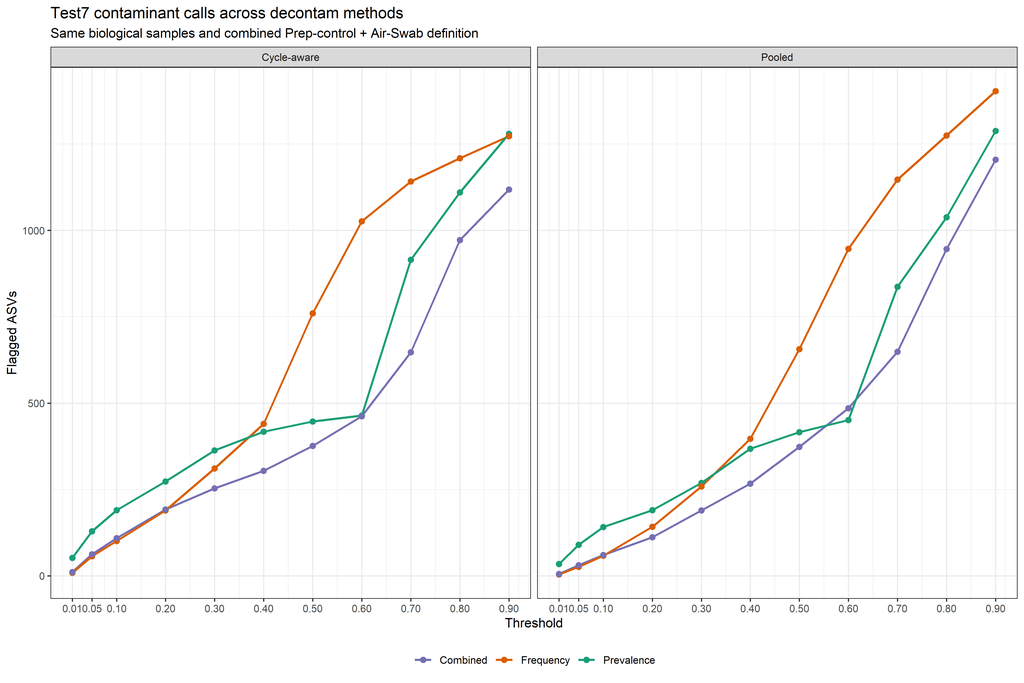

```r
p_sweep <- ggplot(
  threshold_summary,
  aes(threshold, contaminant_features, color = method_label)
) +
  geom_line(linewidth = 0.9) + geom_point(size = 2) +
  facet_wrap(~batch_label) +
  scale_x_continuous(breaks = thresholds) +
  scale_color_manual(values = method_colors[c("Prevalence", "Frequency", "Combined")]) +
  labs(
    title = "Test7 contaminant calls across decontam methods",
    subtitle = "Same biological samples and combined Prep-control + Air-Swab definition",
    x = "Threshold", y = "Flagged ASVs", color = NULL
  ) + theme(legend.position = "bottom")

p_retention <- threshold_summary |>
  select(method_label, batch_label, threshold,
         biological_reads_retained_pct, control_reads_retained_pct) |>
  pivot_longer(ends_with("retained_pct"), names_to = "sample_group", values_to = "retained_pct") |>
  mutate(sample_group = recode(sample_group,
    biological_reads_retained_pct = "Biological samples",
    control_reads_retained_pct = "Negative controls")) |>
  ggplot(aes(threshold, retained_pct, color = method_label)) +
  geom_line(linewidth = 0.9) + geom_point(size = 1.8) +
  facet_grid(sample_group ~ batch_label) +
  scale_x_continuous(breaks = thresholds) +
  scale_color_manual(values = method_colors[c("Prevalence", "Frequency", "Combined")]) +
  labs(title = "Read retention after decontam calls", x = "Threshold",
       y = "Reads retained (%)", color = NULL) +
  theme(legend.position = "bottom")

print(p_sweep)
```

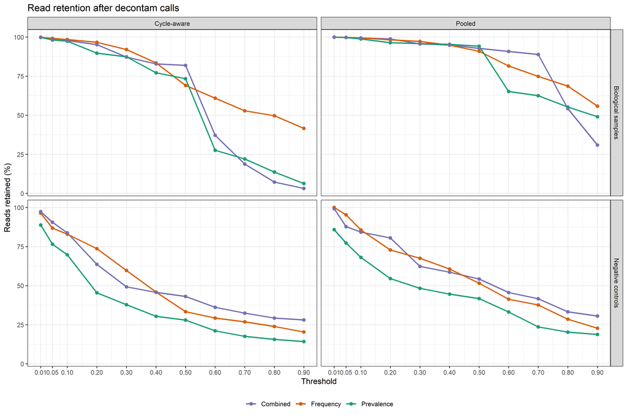

```r
print(p_retention)
```

```r
ggsave(file.path(output_dir, "06_01_decontam_flagged_ASVs.png"), p_sweep,
       width = 12, height = 5.5, dpi = 300)
ggsave(file.path(output_dir, "06_02_decontam_read_retention.png"), p_retention,
       width = 12, height = 8, dpi = 300)
```

## 4.1 Agreement of decontam methods at threshold 0.5

```r
flags_05 <- feature_flags |>
  filter(batch_mode == "pooled", threshold == 0.5) |>
  select(feature_id, method, contaminant) |>
  pivot_wider(names_from = method, values_from = contaminant)

binary_metrics <- function(x, y) {
  intersection <- sum(x & y)
  union <- sum(x | y)
  data.frame(
    n_method_1 = sum(x), n_method_2 = sum(y), overlap = intersection,
    jaccard = ifelse(union == 0, NA_real_, intersection / union),
    agreement = mean(x == y)
  )
}

decontam_pairs <- list(c("prevalence", "frequency"),
                       c("prevalence", "combined"),
                       c("frequency", "combined"))
decontam_agreement <- bind_rows(lapply(decontam_pairs, function(pair) {
  out <- binary_metrics(flags_05[[pair[1]]], flags_05[[pair[2]]])
  out$method_1 <- pair[1]; out$method_2 <- pair[2]; out
})) |>
  select(method_1, method_2, everything())
write_csv(decontam_agreement, file.path(output_dir, "06_06_decontam_agreement_threshold_0.5.csv"))
knitr::kable(decontam_agreement, digits = 3)
```

| method_1 | method_2 | n_method_1 | n_method_2 | overlap | jaccard | agreement |
| --- | --- | --- | --- | --- | --- | --- |
| prevalence | frequency | 416 | 656 | 198 | 0.227 | 0.852 |
| prevalence | combined | 416 | 373 | 235 | 0.424 | 0.930 |
| frequency | combined | 656 | 373 | 226 | 0.281 | 0.874 |

# 5 5. Cross-validation with SCRuB and MicrobIEM

The primary cross-tool comparison uses pooled decontam `combined` at threshold 0.5. MicrobIEM receives Prep controls as NEG1 and Air Swabs as NEG2. Ratio 1 with no explicit minimum span is retained as the prespecified reference result, and a separate ratio-by-span sensitivity grid is reported below. SCRuB is run twice on the identical pooled count table and controls: once without position metadata and once with the 96-well locations reconstructed from `No` using the same column-wise mapping as script 05 (A1–H1, A2–H2, and so on). Thus the only difference between the two SCRuB runs is whether its well-to-well leakage component is enabled. The default Euclidean distance threshold of 1.5 is kept.

```r
combined_flagged <- flags_05$feature_id[flags_05$combined]
original_taxa_reads <- colSums(biological_counts)

combined_removed_taxa <- setNames(numeric(ncol(biological_counts)), colnames(biological_counts))
combined_removed_taxa[combined_flagged] <- original_taxa_reads[combined_flagged]
combined_removed_samples <- rowSums(biological_counts[, combined_flagged, drop = FALSE])

source(microbiem_source)
microbiem_result <- MicrobIEM_decontamination(
  feature_table = data.frame(t(count_matrix), check.names = FALSE),
  SAMPLE = biological_ids,
  NEG1 = prep_ids,
  NEG2 = air_ids,
  ratio_NEG1_threshold = 1,
  ratio_NEG2_threshold = 1,
  span_NEG1_threshold = NA_real_,
  span_NEG2_threshold = NA_real_
)
microbiem_flagged <- rownames(microbiem_result)[microbiem_result$is_contaminant]
microbiem_removed_taxa <- setNames(numeric(ncol(biological_counts)), colnames(biological_counts))
microbiem_removed_taxa[microbiem_flagged] <- original_taxa_reads[microbiem_flagged]
microbiem_removed_samples <- rowSums(biological_counts[, microbiem_flagged, drop = FALSE])

scrub_meta <- data.frame(
  is_control = rownames(count_matrix) %in% control_ids,
  control_type = case_when(
    rownames(count_matrix) %in% prep_ids ~ "Prep control",
    rownames(count_matrix) %in% air_ids ~ "Air Swab",
    TRUE ~ "Biological sample"
  ),
  row.names = rownames(count_matrix)
)
set.seed(42)
scrub_result <- SCRuB::SCRuB(
  count_matrix, scrub_meta,
  control_order = c("Prep control", "Air Swab"),
  verbose = FALSE
)
```

```
## [1] "Did not find well metadata, running SCRuB without the spatial component"
## [1] "SCRuBbing away contamination in the Prep control controls..."
## [1] "SCRuBbing away contamination in the Air Swab controls..."
```

```r
scrub_clean <- scrub_result$decontaminated_samples[
  biological_ids, colnames(biological_counts), drop = FALSE
]
scrub_removed <- pmax(biological_counts - scrub_clean, 0)
scrub_removed_taxa <- colSums(scrub_removed)
scrub_removed_samples <- rowSums(scrub_removed)
rm(scrub_removed); gc()
```

```
##            used  (Mb) gc trigger  (Mb) max used  (Mb)
## Ncells  6329265 338.1   10722265 572.7 10722265 572.7
## Vcells 23520585 179.5   39241361 299.4 39241360 299.4
```

```r
well_lookup <- setNames(scope_info$well, scope_info$sample_id)
scrub_meta_spatial <- scrub_meta
scrub_meta_spatial$well <- unname(well_lookup[rownames(scrub_meta_spatial)])
if (anyNA(scrub_meta_spatial$well) || anyDuplicated(scrub_meta_spatial$well)) {
  stop("SCRuB spatial analysis requires complete, unique well locations.")
}

set.seed(42)
scrub_spatial_result <- SCRuB::SCRuB(
  count_matrix, scrub_meta_spatial,
  control_order = c("Prep control", "Air Swab"),
  dist_threshold = 1.5,
  dist_metric = "euclidean",
  verbose = FALSE
)
```

```
## [1] "Incorporating the well metadata to track well-to-well leakage!"
## [1] "SCRuBbing away contamination in the Prep control controls..."
## [1] "SCRuBbing away contamination in the Air Swab controls..."
```

```r
scrub_spatial_clean <- scrub_spatial_result$decontaminated_samples[
  biological_ids, colnames(biological_counts), drop = FALSE
]
scrub_spatial_removed <- pmax(biological_counts - scrub_spatial_clean, 0)
scrub_spatial_removed_taxa <- colSums(scrub_spatial_removed)
scrub_spatial_removed_samples <- rowSums(scrub_spatial_removed)
rm(scrub_spatial_removed); gc()
```

```
##            used  (Mb) gc trigger  (Mb) max used  (Mb)
## Ncells  6352664 339.3   10722265 572.7 10722265 572.7
## Vcells 24338810 185.7   39241361 299.4 39241360 299.4
```

```r
feature_agreement <- data.frame(
  ASV = colnames(biological_counts),
  original_biological_reads = as.numeric(original_taxa_reads),
  decontam_combined_removed_reads = as.numeric(combined_removed_taxa[colnames(biological_counts)]),
  SCRuB_nonspatial_removed_reads = as.numeric(scrub_removed_taxa[colnames(biological_counts)]),
  SCRuB_spatial_removed_reads = as.numeric(scrub_spatial_removed_taxa[colnames(biological_counts)]),
  MicrobIEM_removed_reads = as.numeric(microbiem_removed_taxa[colnames(biological_counts)]),
  stringsAsFactors = FALSE
) |>
  mutate(
    decontam_combined_removed_fraction = if_else(original_biological_reads > 0,
      decontam_combined_removed_reads / original_biological_reads, 0),
    SCRuB_nonspatial_removed_fraction = if_else(original_biological_reads > 0,
      SCRuB_nonspatial_removed_reads / original_biological_reads, 0),
    SCRuB_spatial_removed_fraction = if_else(original_biological_reads > 0,
      SCRuB_spatial_removed_reads / original_biological_reads, 0),
    MicrobIEM_removed_fraction = if_else(original_biological_reads > 0,
      MicrobIEM_removed_reads / original_biological_reads, 0),
    decontam_combined_call = ASV %in% combined_flagged,
    MicrobIEM_call = ASV %in% microbiem_flagged,
    SCRuB_nonspatial_any = SCRuB_nonspatial_removed_reads > 1e-8,
    SCRuB_nonspatial_ge_50pct = SCRuB_nonspatial_removed_fraction >= 0.50,
    SCRuB_spatial_any = SCRuB_spatial_removed_reads > 1e-8,
    SCRuB_spatial_ge_10pct = SCRuB_spatial_removed_fraction >= 0.10,
    SCRuB_spatial_ge_50pct = SCRuB_spatial_removed_fraction >= 0.50,
    SCRuB_spatial_ge_90pct = SCRuB_spatial_removed_fraction >= 0.90
  )

taxonomy_df <- data.frame(tax_table(ps_scope), check.names = FALSE, stringsAsFactors = FALSE)
taxonomy_df$ASV <- rownames(taxonomy_df)
feature_agreement <- left_join(feature_agreement, taxonomy_df, by = "ASV")
write_csv(feature_agreement, file.path(output_dir, "06_07_cross_method_ASV_agreement.csv"))

method_summary <- data.frame(
  method = c("decontam combined", "SCRuB non-spatial", "SCRuB spatial", "MicrobIEM"),
  binary_rule = c("threshold 0.5", "any removed read", "any removed read",
                  "NEG1 or NEG2 ratio > 1"),
  n_flagged_or_affected_ASVs = c(sum(feature_agreement$decontam_combined_call),
    sum(feature_agreement$SCRuB_nonspatial_any),
    sum(feature_agreement$SCRuB_spatial_any), sum(feature_agreement$MicrobIEM_call)),
  biological_reads_removed = c(sum(combined_removed_taxa), sum(scrub_removed_taxa),
    sum(scrub_spatial_removed_taxa), sum(microbiem_removed_taxa)),
  biological_reads_removed_pct = 100 * c(sum(combined_removed_taxa),
    sum(scrub_removed_taxa), sum(scrub_spatial_removed_taxa),
    sum(microbiem_removed_taxa)) / sum(biological_counts)
)
write_csv(method_summary, file.path(output_dir, "06_08_cross_method_summary.csv"))
knitr::kable(method_summary, digits = 3, format.args = list(big.mark = ","))
```

| method | binary_rule | n_flagged_or_affected_ASVs | biological_reads_removed | biological_reads_removed_pct |
| --- | --- | --- | --- | --- |
| decontam combined | threshold 0.5 | 373 | 148,717 | 7.179 |
| SCRuB non-spatial | any removed read | 1,995 | 225,412 | 10.881 |
| SCRuB spatial | any removed read | 2,217 | 120,134 | 5.799 |
| MicrobIEM | NEG1 or NEG2 ratio > 1 | 911 | 216,479 | 10.450 |

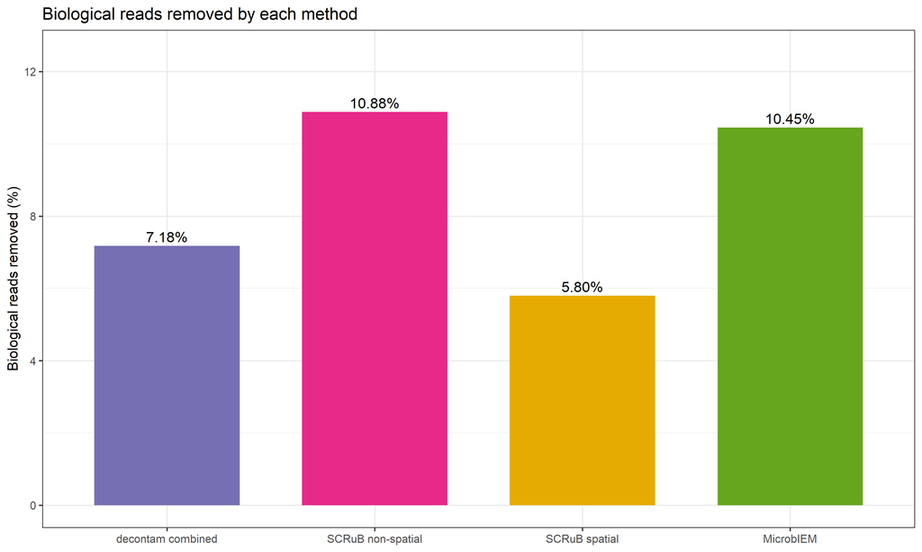

```r
p_method <- method_summary |>
  mutate(method = factor(method, levels = method)) |>
  ggplot(aes(method, biological_reads_removed_pct, fill = method)) +
  geom_col(width = 0.7) +
  geom_text(aes(label = sprintf("%.2f%%", biological_reads_removed_pct)),
            vjust = -0.35, size = 4) +
  scale_fill_manual(values = c("#7570B3", "#E7298A", "#E6AB02", "#66A61E")) +
  labs(title = "Biological reads removed by each method", x = NULL,
       y = "Biological reads removed (%)") +
  theme(legend.position = "none") +
  coord_cartesian(ylim = c(0, max(method_summary$biological_reads_removed_pct) * 1.15 + 0.01))
print(p_method)
```

```r
ggsave(file.path(output_dir, "06_03_cross_method_read_removal.png"), p_method,
       width = 8, height = 5, dpi = 300)
```

## 5.1 MicrobIEM ratio and span threshold sensitivity

MicrobIEM does not use a decontam-like probability threshold. Its ratio is the mean relative abundance in a negative-control class divided by the mean relative abundance in biological samples. Thus a ratio threshold of 1 flags an ASV when it is more abundant in at least one control class than in biological samples. The span threshold is the minimum fraction of controls in which that ASV must be detected. `NA` below means no explicit minimum span beyond being detected in at least one control, matching the reference call used above.

The same ratio and span settings are applied to Prep controls (NEG1) and Air Swabs (NEG2). These settings are a sensitivity grid, not candidate values of a decontam threshold and not an optimization exercise.

```r
microbiem_ratio_thresholds <- c(0.25, 0.5, 0.75, 1, 1.5, 2, 3, 5, 10)
microbiem_span_thresholds <- c(NA_real_, 0.25, 0.5, 0.75, 1)

microbiem_grid <- expand.grid(
  ratio_threshold = microbiem_ratio_thresholds,
  span_threshold = microbiem_span_thresholds,
  KEEP.OUT.ATTRS = FALSE,
  stringsAsFactors = FALSE
)

microbiem_sensitivity_rows <- vector("list", nrow(microbiem_grid))
microbiem_flag_rows <- vector("list", nrow(microbiem_grid))

for (i in seq_len(nrow(microbiem_grid))) {
  ratio_value <- microbiem_grid$ratio_threshold[i]
  span_value <- microbiem_grid$span_threshold[i]
  fit <- MicrobIEM_decontamination(
    feature_table = data.frame(t(count_matrix), check.names = FALSE),
    SAMPLE = biological_ids,
    NEG1 = prep_ids,
    NEG2 = air_ids,
    ratio_NEG1_threshold = ratio_value,
    ratio_NEG2_threshold = ratio_value,
    span_NEG1_threshold = span_value,
    span_NEG2_threshold = span_value
  )
  flagged <- rownames(fit)[fit$is_contaminant]
  removed_reads <- sum(original_taxa_reads[flagged])
  intersection_n <- length(intersect(flagged, combined_flagged))
  union_n <- length(union(flagged, combined_flagged))

  microbiem_sensitivity_rows[[i]] <- data.frame(
    ratio_threshold = ratio_value,
    span_threshold = span_value,
    span_label = ifelse(is.na(span_value), "Any detected", as.character(span_value)),
    n_flagged_ASVs = length(flagged),
    biological_reads_removed = removed_reads,
    biological_reads_removed_pct = 100 * removed_reads / sum(biological_counts),
    overlap_with_decontam_combined = intersection_n,
    jaccard_with_decontam_combined = ifelse(union_n == 0, NA_real_, intersection_n / union_n),
    stringsAsFactors = FALSE
  )
  microbiem_flag_rows[[i]] <- data.frame(
    ratio_threshold = ratio_value,
    span_threshold = span_value,
    span_label = ifelse(is.na(span_value), "Any detected", as.character(span_value)),
    ASV = colnames(biological_counts),
    contaminant = colnames(biological_counts) %in% flagged,
    stringsAsFactors = FALSE
  )
}

microbiem_sensitivity <- bind_rows(microbiem_sensitivity_rows) |>
  mutate(
    span_label = factor(
      span_label,
      levels = c("Any detected", "0.25", "0.5", "0.75", "1")
    ),
    reference_setting = ratio_threshold == 1 & span_label == "Any detected"
  )
microbiem_sensitivity_flags <- bind_rows(microbiem_flag_rows)

write_csv(
  microbiem_sensitivity,
  file.path(output_dir, "06_14_MicrobIEM_threshold_sensitivity.csv")
)
write_csv(
  microbiem_sensitivity_flags,
  file.path(output_dir, "06_15_MicrobIEM_threshold_feature_flags.csv")
)

knitr::kable(
  microbiem_sensitivity |>
    select(ratio_threshold, span_label, n_flagged_ASVs,
           biological_reads_removed_pct, jaccard_with_decontam_combined),
  digits = 3
)
```

| ratio_threshold | span_label | n_flagged_ASVs | biological_reads_removed_pct | jaccard_with_decontam_combined |
| --- | --- | --- | --- | --- |
| 0.25 | Any detected | 955 | 62.549 | 0.283 |
| 0.50 | Any detected | 939 | 13.313 | 0.280 |
| 0.75 | Any detected | 927 | 12.321 | 0.277 |
| 1.00 | Any detected | 911 | 10.450 | 0.273 |
| 1.50 | Any detected | 880 | 8.894 | 0.259 |
| 2.00 | Any detected | 850 | 8.031 | 0.244 |
| 3.00 | Any detected | 802 | 7.112 | 0.213 |
| 5.00 | Any detected | 712 | 4.097 | 0.167 |
| 10.00 | Any detected | 631 | 1.033 | 0.124 |
| 0.25 | 0.25 | 150 | 56.451 | 0.239 |
| 0.50 | 0.25 | 142 | 7.653 | 0.235 |
| 0.75 | 0.25 | 140 | 7.509 | 0.230 |
| 1.00 | 0.25 | 136 | 6.654 | 0.227 |
| 1.50 | 0.25 | 129 | 5.807 | 0.221 |
| 2.00 | 0.25 | 124 | 5.362 | 0.218 |
| 3.00 | 0.25 | 111 | 4.927 | 0.195 |
| 5.00 | 0.25 | 87 | 3.062 | 0.162 |
| 10.00 | 0.25 | 60 | 0.477 | 0.105 |
| 0.25 | 0.5 | 54 | 54.442 | 0.095 |
| 0.50 | 0.5 | 48 | 5.808 | 0.094 |
| 0.75 | 0.5 | 48 | 5.808 | 0.094 |
| 1.00 | 0.5 | 47 | 5.071 | 0.094 |
| 1.50 | 0.5 | 43 | 4.325 | 0.092 |
| 2.00 | 0.5 | 41 | 4.169 | 0.087 |
| 3.00 | 0.5 | 37 | 3.989 | 0.079 |
| 5.00 | 0.5 | 24 | 2.580 | 0.056 |
| 10.00 | 0.5 | 12 | 0.298 | 0.032 |
| 0.25 | 0.75 | 20 | 45.887 | 0.034 |
| 0.50 | 0.75 | 16 | 3.682 | 0.035 |
| 0.75 | 0.75 | 16 | 3.682 | 0.035 |
| 1.00 | 0.75 | 16 | 3.682 | 0.035 |
| 1.50 | 0.75 | 15 | 3.347 | 0.035 |
| 2.00 | 0.75 | 14 | 3.310 | 0.032 |
| 3.00 | 0.75 | 14 | 3.310 | 0.032 |
| 5.00 | 0.75 | 8 | 2.116 | 0.019 |
| 10.00 | 0.75 | 2 | 0.099 | 0.005 |
| 0.25 | 1 | 10 | 36.002 | 0.019 |
| 0.50 | 1 | 8 | 2.675 | 0.019 |
| 0.75 | 1 | 8 | 2.675 | 0.019 |
| 1.00 | 1 | 8 | 2.675 | 0.019 |
| 1.50 | 1 | 7 | 2.340 | 0.019 |
| 2.00 | 1 | 7 | 2.340 | 0.019 |
| 3.00 | 1 | 7 | 2.340 | 0.019 |
| 5.00 | 1 | 5 | 1.360 | 0.013 |
| 10.00 | 1 | 2 | 0.099 | 0.005 |

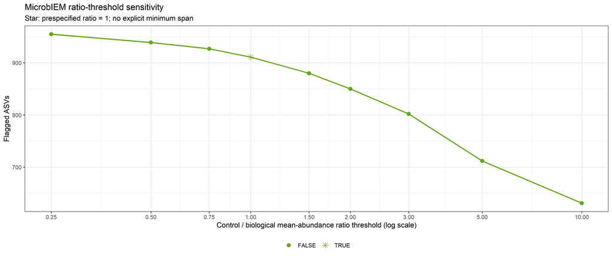

```r
p_microbiem_ratio <- microbiem_sensitivity |>
  filter(span_label == "Any detected") |>
  ggplot(aes(ratio_threshold, n_flagged_ASVs)) +
  geom_line(color = "#66A61E", linewidth = 0.9) +
  geom_point(aes(shape = reference_setting), color = "#66A61E", size = 2.8) +
  scale_x_log10(breaks = microbiem_ratio_thresholds) +
  scale_shape_manual(values = c(`FALSE` = 16, `TRUE` = 8)) +
  labs(
    title = "MicrobIEM ratio-threshold sensitivity",
    subtitle = "Star: prespecified ratio = 1; no explicit minimum span",
    x = "Control / biological mean-abundance ratio threshold (log scale)",
    y = "Flagged ASVs", shape = NULL
  ) + theme(legend.position = "bottom")

p_microbiem_grid <- ggplot(
  microbiem_sensitivity,
  aes(factor(ratio_threshold, levels = microbiem_ratio_thresholds),
      span_label, fill = biological_reads_removed_pct)
) +
  geom_tile(color = "white") +
  geom_text(aes(label = sprintf("%.1f%%", biological_reads_removed_pct)), size = 3) +
  scale_fill_gradient(low = "white", high = "#238B45") +
  labs(
    title = "MicrobIEM ratio-by-span sensitivity",
    x = "Ratio threshold", y = "Minimum control span",
    fill = "Biological reads\nremoved (%)"
  )

print(p_microbiem_ratio)
```

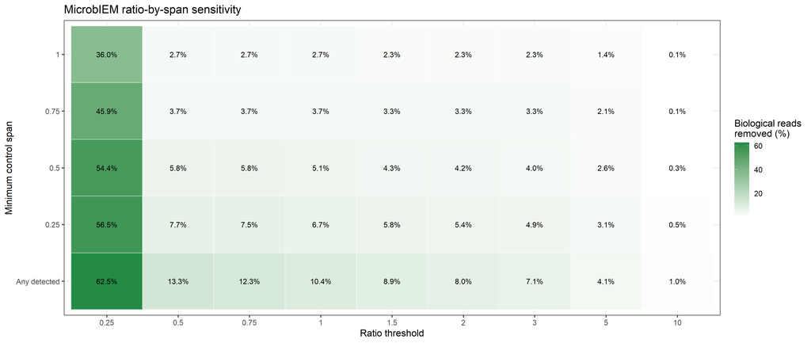

```r
print(p_microbiem_grid)
```

```r
ggsave(file.path(output_dir, "06_07_MicrobIEM_ratio_sensitivity.png"),
       p_microbiem_ratio, width = 9, height = 5.5, dpi = 300)
ggsave(file.path(output_dir, "06_08_MicrobIEM_ratio_span_heatmap.png"),
       p_microbiem_grid, width = 11, height = 5.5, dpi = 300)
```

## 5.2 Non-spatial SCRuB removal-fraction sensitivity

SCRuB has no decontam-like classification threshold when well positions are absent. It estimates a continuous number of removed reads for every sample-by-ASV entry. To make its binary agreement with the other tools auditable, the single non-spatial SCRuB fit is summarized over prespecified global ASV removal-fraction cutoffs. These are post-estimation reporting cutoffs; SCRuB is not refitted at each value.

```r
scrub_nonspatial_thresholds <- thresholds
scrub_nonspatial_rows <- vector("list", length(scrub_nonspatial_thresholds))
scrub_nonspatial_flag_rows <- vector("list", length(scrub_nonspatial_thresholds))

for (i in seq_along(scrub_nonspatial_thresholds)) {
  cutoff <- scrub_nonspatial_thresholds[i]
  scrub_call <- feature_agreement$SCRuB_nonspatial_removed_fraction >= cutoff
  decontam_call <- feature_agreement$decontam_combined_call
  microbiem_call <- feature_agreement$MicrobIEM_call

  jaccard_binary <- function(x, y) {
    denominator <- sum(x | y)
    if (denominator == 0) return(NA_real_)
    sum(x & y) / denominator
  }

  scrub_nonspatial_rows[[i]] <- data.frame(
    removal_fraction_cutoff = cutoff,
    n_affected_ASVs = sum(scrub_call),
    SCRuB_removed_reads_in_affected_ASVs = sum(
      feature_agreement$SCRuB_nonspatial_removed_reads[scrub_call]
    ),
    SCRuB_removed_reads_pct_of_all_biological_reads = 100 * sum(
      feature_agreement$SCRuB_nonspatial_removed_reads[scrub_call]
    ) / sum(biological_counts),
    jaccard_with_decontam_combined = jaccard_binary(scrub_call, decontam_call),
    jaccard_with_MicrobIEM_ratio1 = jaccard_binary(scrub_call, microbiem_call),
    stringsAsFactors = FALSE
  )
  scrub_nonspatial_flag_rows[[i]] <- data.frame(
    removal_fraction_cutoff = cutoff,
    ASV = feature_agreement$ASV,
    affected = scrub_call,
    stringsAsFactors = FALSE
  )
}

scrub_nonspatial_sensitivity <- bind_rows(scrub_nonspatial_rows)
scrub_nonspatial_sensitivity_flags <- bind_rows(scrub_nonspatial_flag_rows)

write_csv(
  scrub_nonspatial_sensitivity,
  file.path(output_dir, "06_16_SCRuB_nonspatial_threshold_sensitivity.csv")
)
write_csv(
  scrub_nonspatial_sensitivity_flags,
  file.path(output_dir, "06_17_SCRuB_nonspatial_threshold_feature_flags.csv")
)
knitr::kable(scrub_nonspatial_sensitivity, digits = 3)
```

| removal_fraction_cutoff | n_affected_ASVs | SCRuB_removed_reads_in_affected_ASVs | SCRuB_removed_reads_pct_of_all_biological_reads | jaccard_with_decontam_combined | jaccard_with_MicrobIEM_ratio1 |
| --- | --- | --- | --- | --- | --- |
| 0.01 | 1952 | 224738 | 10.848 | 0.131 | 0.153 |
| 0.05 | 1841 | 221315 | 10.683 | 0.129 | 0.146 |
| 0.10 | 1754 | 156047 | 7.533 | 0.122 | 0.137 |
| 0.20 | 1635 | 120704 | 5.826 | 0.103 | 0.121 |
| 0.30 | 1535 | 84174 | 4.063 | 0.090 | 0.107 |
| 0.40 | 1469 | 70152 | 3.386 | 0.075 | 0.094 |
| 0.50 | 1408 | 59864 | 2.890 | 0.060 | 0.079 |
| 0.60 | 1359 | 43055 | 2.078 | 0.048 | 0.067 |
| 0.70 | 1328 | 33853 | 1.634 | 0.041 | 0.059 |
| 0.80 | 1310 | 29240 | 1.411 | 0.037 | 0.052 |
| 0.90 | 1298 | 26736 | 1.291 | 0.033 | 0.049 |

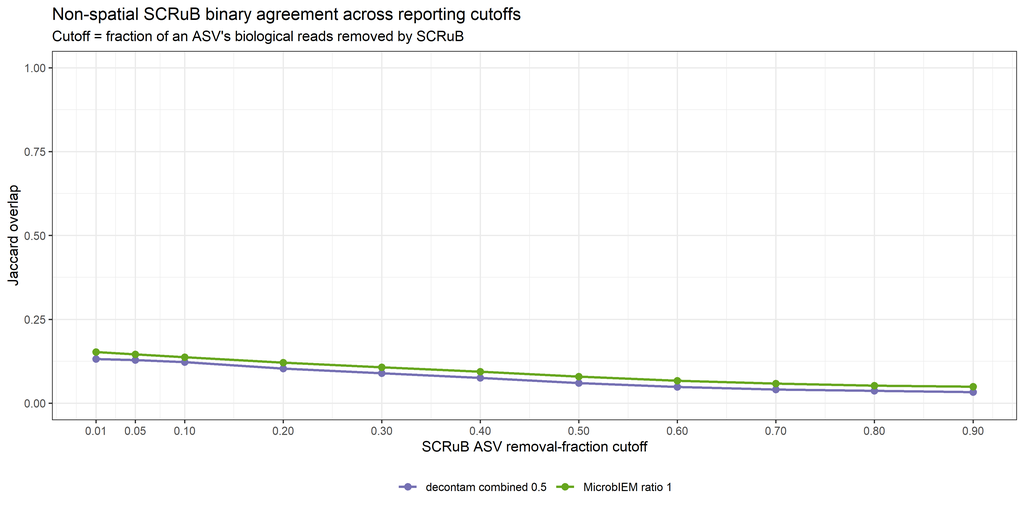

```r
p_scrub_nonspatial <- scrub_nonspatial_sensitivity |>
  select(removal_fraction_cutoff, jaccard_with_decontam_combined,
         jaccard_with_MicrobIEM_ratio1) |>
  pivot_longer(starts_with("jaccard_"), names_to = "comparison", values_to = "jaccard") |>
  mutate(comparison = recode(
    comparison,
    jaccard_with_decontam_combined = "decontam combined 0.5",
    jaccard_with_MicrobIEM_ratio1 = "MicrobIEM ratio 1"
  )) |>
  ggplot(aes(removal_fraction_cutoff, jaccard, color = comparison)) +
  geom_line(linewidth = 0.9) + geom_point(size = 2.2) +
  scale_x_continuous(breaks = scrub_nonspatial_thresholds) +
  scale_y_continuous(limits = c(0, 1)) +
  scale_color_manual(values = c(
    "decontam combined 0.5" = "#7570B3",
    "MicrobIEM ratio 1" = "#66A61E"
  )) +
  labs(
    title = "Non-spatial SCRuB binary agreement across reporting cutoffs",
    subtitle = "Cutoff = fraction of an ASV's biological reads removed by SCRuB",
    x = "SCRuB ASV removal-fraction cutoff", y = "Jaccard overlap",
    color = NULL
  ) + theme(legend.position = "bottom")

p_scrub_nonspatial_count <- ggplot(
  scrub_nonspatial_sensitivity,
  aes(removal_fraction_cutoff, n_affected_ASVs)
) +
  geom_line(color = "#E7298A", linewidth = 0.9) +
  geom_point(color = "#E7298A", size = 2.2) +
  scale_x_continuous(breaks = scrub_nonspatial_thresholds) +
  labs(
    title = "Non-spatial SCRuB affected ASVs",
    x = "SCRuB ASV removal-fraction cutoff", y = "Affected ASVs"
  )

print(p_scrub_nonspatial)
```

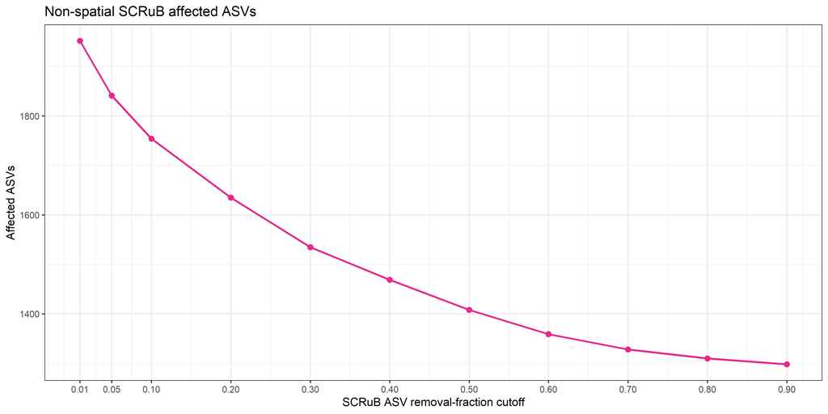

```r
print(p_scrub_nonspatial_count)
```

```r
ggsave(file.path(output_dir, "06_09_SCRuB_nonspatial_threshold_agreement.png"),
       p_scrub_nonspatial, width = 10, height = 5.5, dpi = 300)
ggsave(file.path(output_dir, "06_10_SCRuB_nonspatial_threshold_ASVs.png"),
       p_scrub_nonspatial_count, width = 9, height = 5.5, dpi = 300)
```

## 5.3 Common-scale comparison of all five methods

The numerical thresholds are not interchangeable across tools. Accordingly, all five methods are placed on common outcome axes: the percentage of biological reads removed and the number of ASVs classified or affected. The decontam curves use pooled calls, MicrobIEM uses the ratio sweep with no explicit minimum span, and SCRuB uses the non-spatial removal-fraction sweep. For SCRuB, removed reads are its estimated removed counts within ASVs passing the reporting cutoff; for binary methods, all reads belonging to a flagged ASV are counted as removed.

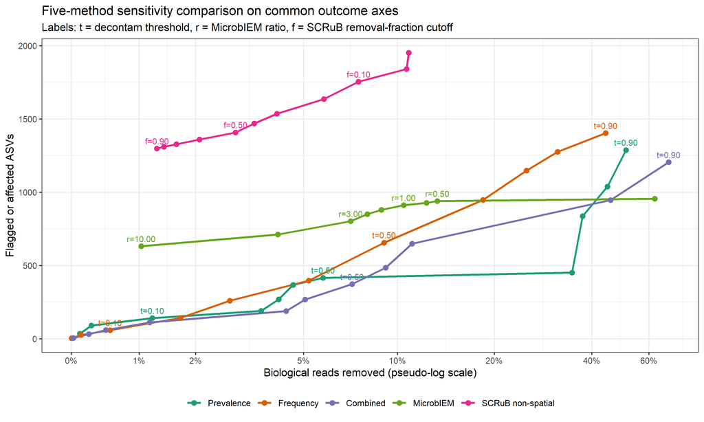

```r
decontam_common <- threshold_summary |>
  filter(batch_mode == "pooled") |>
  transmute(
    method = method_label,
    threshold_parameter = "decontam threshold",
    threshold_value = threshold,
    threshold_label = paste0("t=", format(threshold, trim = TRUE)),
    n_affected_ASVs = contaminant_features,
    biological_reads_removed_pct = 100 - biological_reads_retained_pct
  )

microbiem_common <- microbiem_sensitivity |>
  filter(span_label == "Any detected") |>
  transmute(
    method = "MicrobIEM",
    threshold_parameter = "ratio threshold",
    threshold_value = ratio_threshold,
    threshold_label = paste0("r=", format(ratio_threshold, trim = TRUE)),
    n_affected_ASVs = n_flagged_ASVs,
    biological_reads_removed_pct = biological_reads_removed_pct
  )

scrub_common <- scrub_nonspatial_sensitivity |>
  transmute(
    method = "SCRuB non-spatial",
    threshold_parameter = "ASV removal-fraction cutoff",
    threshold_value = removal_fraction_cutoff,
    threshold_label = paste0("f=", format(removal_fraction_cutoff, trim = TRUE)),
    n_affected_ASVs = n_affected_ASVs,
    biological_reads_removed_pct = SCRuB_removed_reads_pct_of_all_biological_reads
  )

common_scale_sensitivity <- bind_rows(
  decontam_common, microbiem_common, scrub_common
) |>
  mutate(method = factor(
    method,
    levels = c("Prevalence", "Frequency", "Combined", "MicrobIEM", "SCRuB non-spatial")
  ))

label_points <- common_scale_sensitivity |>
  filter(
    method %in% c("Prevalence", "Frequency", "Combined") &
      threshold_value %in% c(0.1, 0.5, 0.9) |
    method == "MicrobIEM" & threshold_value %in% c(0.5, 1, 3, 10) |
    method == "SCRuB non-spatial" & threshold_value %in% c(0.1, 0.5, 0.9)
  )

write_csv(
  common_scale_sensitivity,
  file.path(output_dir, "06_18_cross_method_sensitivity_common_scale.csv")
)

p_common_scale <- ggplot(
  common_scale_sensitivity,
  aes(biological_reads_removed_pct, n_affected_ASVs, color = method, group = method)
) +
  geom_line(linewidth = 0.95) +
  geom_point(size = 2.2) +
  geom_text(
    data = label_points,
    aes(label = threshold_label),
    size = 3, vjust = -0.7, check_overlap = TRUE, show.legend = FALSE
  ) +
  scale_x_continuous(
    trans = scales::pseudo_log_trans(base = 10),
    breaks = c(0, 1, 2, 5, 10, 20, 40, 60),
    labels = function(x) paste0(x, "%")
  ) +
  scale_color_manual(values = c(
    Prevalence = "#1B9E77", Frequency = "#D95F02", Combined = "#7570B3",
    MicrobIEM = "#66A61E", `SCRuB non-spatial` = "#E7298A"
  )) +
  labs(
    title = "Five-method sensitivity comparison on common outcome axes",
    subtitle = "Labels: t = decontam threshold, r = MicrobIEM ratio, f = SCRuB removal-fraction cutoff",
    x = "Biological reads removed (pseudo-log scale)",
    y = "Flagged or affected ASVs", color = NULL
  ) +
  theme(legend.position = "bottom")

print(p_common_scale)
```

```r
ggsave(
  file.path(output_dir, "06_11_cross_method_sensitivity_common_scale.png"),
  p_common_scale, width = 12, height = 7, dpi = 300
)
knitr::kable(common_scale_sensitivity, digits = 3)
```

| method | threshold_parameter | threshold_value | threshold_label | n_affected_ASVs | biological_reads_removed_pct |
| --- | --- | --- | --- | --- | --- |
| Prevalence | decontam threshold | 0.01 | t=0.01 | 34 | 0.121 |
| Prevalence | decontam threshold | 0.05 | t=0.05 | 90 | 0.287 |
| Prevalence | decontam threshold | 0.10 | t=0.10 | 141 | 1.215 |
| Prevalence | decontam threshold | 0.20 | t=0.20 | 190 | 3.580 |
| Prevalence | decontam threshold | 0.30 | t=0.30 | 269 | 4.123 |
| Prevalence | decontam threshold | 0.40 | t=0.40 | 368 | 4.616 |
| Prevalence | decontam threshold | 0.50 | t=0.50 | 416 | 5.794 |
| Prevalence | decontam threshold | 0.60 | t=0.60 | 451 | 34.765 |
| Prevalence | decontam threshold | 0.70 | t=0.70 | 837 | 37.460 |
| Prevalence | decontam threshold | 0.80 | t=0.80 | 1038 | 44.720 |
| Prevalence | decontam threshold | 0.90 | t=0.90 | 1288 | 50.962 |
| Frequency | decontam threshold | 0.01 | t=0.01 | 4 | 0.006 |
| Frequency | decontam threshold | 0.05 | t=0.05 | 26 | 0.139 |
| Frequency | decontam threshold | 0.10 | t=0.10 | 58 | 0.558 |
| Frequency | decontam threshold | 0.20 | t=0.20 | 142 | 1.706 |
| Frequency | decontam threshold | 0.30 | t=0.30 | 259 | 2.754 |
| Frequency | decontam threshold | 0.40 | t=0.40 | 397 | 5.201 |
| Frequency | decontam threshold | 0.50 | t=0.50 | 656 | 9.077 |
| Frequency | decontam threshold | 0.60 | t=0.60 | 947 | 18.466 |
| Frequency | decontam threshold | 0.70 | t=0.70 | 1147 | 25.138 |
| Frequency | decontam threshold | 0.80 | t=0.80 | 1275 | 31.379 |
| Frequency | decontam threshold | 0.90 | t=0.90 | 1403 | 44.145 |
| Combined | decontam threshold | 0.01 | t=0.01 | 5 | 0.030 |
| Combined | decontam threshold | 0.05 | t=0.05 | 31 | 0.252 |
| Combined | decontam threshold | 0.10 | t=0.10 | 60 | 0.497 |
| Combined | decontam threshold | 0.20 | t=0.20 | 112 | 1.170 |
| Combined | decontam threshold | 0.30 | t=0.30 | 189 | 4.369 |
| Combined | decontam threshold | 0.40 | t=0.40 | 267 | 5.059 |
| Combined | decontam threshold | 0.50 | t=0.50 | 373 | 7.179 |
| Combined | decontam threshold | 0.60 | t=0.60 | 485 | 9.185 |
| Combined | decontam threshold | 0.70 | t=0.70 | 649 | 11.111 |
| Combined | decontam threshold | 0.80 | t=0.80 | 946 | 45.717 |
| Combined | decontam threshold | 0.90 | t=0.90 | 1205 | 69.031 |
| MicrobIEM | ratio threshold | 0.25 | r=0.25 | 955 | 62.549 |
| MicrobIEM | ratio threshold | 0.50 | r=0.50 | 939 | 13.313 |
| MicrobIEM | ratio threshold | 0.75 | r=0.75 | 927 | 12.321 |
| MicrobIEM | ratio threshold | 1.00 | r=1.00 | 911 | 10.450 |
| MicrobIEM | ratio threshold | 1.50 | r=1.50 | 880 | 8.894 |
| MicrobIEM | ratio threshold | 2.00 | r=2.00 | 850 | 8.031 |
| MicrobIEM | ratio threshold | 3.00 | r=3.00 | 802 | 7.112 |
| MicrobIEM | ratio threshold | 5.00 | r=5.00 | 712 | 4.097 |
| MicrobIEM | ratio threshold | 10.00 | r=10.00 | 631 | 1.033 |
| SCRuB non-spatial | ASV removal-fraction cutoff | 0.01 | f=0.01 | 1952 | 10.848 |
| SCRuB non-spatial | ASV removal-fraction cutoff | 0.05 | f=0.05 | 1841 | 10.683 |
| SCRuB non-spatial | ASV removal-fraction cutoff | 0.10 | f=0.10 | 1754 | 7.533 |
| SCRuB non-spatial | ASV removal-fraction cutoff | 0.20 | f=0.20 | 1635 | 5.826 |
| SCRuB non-spatial | ASV removal-fraction cutoff | 0.30 | f=0.30 | 1535 | 4.063 |
| SCRuB non-spatial | ASV removal-fraction cutoff | 0.40 | f=0.40 | 1469 | 3.386 |
| SCRuB non-spatial | ASV removal-fraction cutoff | 0.50 | f=0.50 | 1408 | 2.890 |
| SCRuB non-spatial | ASV removal-fraction cutoff | 0.60 | f=0.60 | 1359 | 2.078 |
| SCRuB non-spatial | ASV removal-fraction cutoff | 0.70 | f=0.70 | 1328 | 1.634 |
| SCRuB non-spatial | ASV removal-fraction cutoff | 0.80 | f=0.80 | 1310 | 1.411 |
| SCRuB non-spatial | ASV removal-fraction cutoff | 0.90 | f=0.90 | 1298 | 1.291 |

## 5.4 Continuous and binary agreement

```r
weighted_jaccard <- function(x, y) {
  denominator <- sum(pmax(x, y))
  if (denominator == 0) return(NA_real_)
  sum(pmin(x, y)) / denominator
}

fraction_matrix <- feature_agreement |>
  select(decontam_combined_removed_fraction, SCRuB_nonspatial_removed_fraction,
         SCRuB_spatial_removed_fraction,
         MicrobIEM_removed_fraction)
colnames(fraction_matrix) <- c(
  "decontam combined", "SCRuB non-spatial", "SCRuB spatial", "MicrobIEM"
)
tool_pairs <- combn(colnames(fraction_matrix), 2, simplify = FALSE)

continuous_agreement <- bind_rows(lapply(tool_pairs, function(pair) {
  x <- fraction_matrix[[pair[1]]]; y <- fraction_matrix[[pair[2]]]
  data.frame(
    method_1 = pair[1], method_2 = pair[2],
    Spearman_rho = suppressWarnings(cor(x, y, method = "spearman")),
    weighted_Jaccard = weighted_jaccard(x, y)
  )
}))

binary_cross_agreement <- bind_rows(
  cbind(comparison = "decontam combined vs MicrobIEM",
        binary_metrics(feature_agreement$decontam_combined_call,
                       feature_agreement$MicrobIEM_call)),
  cbind(comparison = "decontam combined vs SCRuB spatial >=10%",
        binary_metrics(feature_agreement$decontam_combined_call,
                       feature_agreement$SCRuB_spatial_ge_10pct)),
  cbind(comparison = "decontam combined vs SCRuB spatial >=50%",
        binary_metrics(feature_agreement$decontam_combined_call,
                       feature_agreement$SCRuB_spatial_ge_50pct)),
  cbind(comparison = "decontam combined vs SCRuB spatial >=90%",
        binary_metrics(feature_agreement$decontam_combined_call,
                       feature_agreement$SCRuB_spatial_ge_90pct)),
  cbind(comparison = "MicrobIEM vs SCRuB spatial >=50%",
        binary_metrics(feature_agreement$MicrobIEM_call,
                       feature_agreement$SCRuB_spatial_ge_50pct)),
  cbind(comparison = "SCRuB non-spatial vs spatial >=50%",
        binary_metrics(feature_agreement$SCRuB_nonspatial_ge_50pct,
                       feature_agreement$SCRuB_spatial_ge_50pct))
)
write_csv(continuous_agreement, file.path(output_dir, "06_09_continuous_agreement.csv"))
write_csv(binary_cross_agreement, file.path(output_dir, "06_10_binary_agreement.csv"))
knitr::kable(continuous_agreement, digits = 3)
```

| method_1 | method_2 | Spearman_rho | weighted_Jaccard |
| --- | --- | --- | --- |
| decontam combined | SCRuB non-spatial | 0.098 | 0.071 |
| decontam combined | SCRuB spatial | 0.081 | 0.063 |
| decontam combined | MicrobIEM | 0.608 | 0.468 |
| SCRuB non-spatial | SCRuB spatial | 0.662 | 0.644 |
| SCRuB non-spatial | MicrobIEM | 0.162 | 0.108 |
| SCRuB spatial | MicrobIEM | 0.121 | 0.089 |

```r
knitr::kable(binary_cross_agreement, digits = 3)
```

| comparison | n_method_1 | n_method_2 | overlap | jaccard | agreement |
| --- | --- | --- | --- | --- | --- |
| decontam combined vs MicrobIEM | 373 | 911 | 275 | 0.273 | 0.839 |
| decontam combined vs SCRuB spatial >=10% | 373 | 1704 | 202 | 0.108 | 0.634 |
| decontam combined vs SCRuB spatial >=50% | 373 | 1390 | 94 | 0.056 | 0.655 |
| decontam combined vs SCRuB spatial >=90% | 373 | 1288 | 45 | 0.028 | 0.656 |
| MicrobIEM vs SCRuB spatial >=50% | 911 | 1390 | 142 | 0.066 | 0.559 |
| SCRuB non-spatial vs spatial >=50% | 1408 | 1390 | 1087 | 0.635 | 0.863 |

## 5.5 Direct five-method ASV intersections

Low Jaccard values do not mean that the intersections are empty. Jaccard uses the union as its denominator, and SCRuB affects a much broader ASV set than the binary callers. The primary display below uses pooled decontam threshold 0.5, MicrobIEM ratio 1 with no explicit minimum span, and the non-spatial SCRuB 10% ASV removal-fraction reporting cutoff. The latter is a descriptive cutoff, not an internal SCRuB fitting threshold.

```r
agreement_index <- match(flags_05$feature_id, feature_agreement$ASV)
five_method_calls <- data.frame(
  ASV = flags_05$feature_id,
  Prevalence = flags_05$prevalence,
  Frequency = flags_05$frequency,
  Combined = flags_05$combined,
  MicrobIEM = feature_agreement$MicrobIEM_call[agreement_index],
  `SCRuB >=10%` = feature_agreement$SCRuB_nonspatial_removed_fraction[agreement_index] >= 0.10,
  check.names = FALSE
)

call_names <- colnames(five_method_calls)[-1]
pair_grid <- expand.grid(
  method_1 = call_names, method_2 = call_names,
  stringsAsFactors = FALSE
)
five_method_pairwise <- bind_rows(lapply(seq_len(nrow(pair_grid)), function(i) {
  method_1 <- pair_grid$method_1[i]
  method_2 <- pair_grid$method_2[i]
  x <- five_method_calls[[method_1]]
  y <- five_method_calls[[method_2]]
  intersection_n <- sum(x & y)
  union_n <- sum(x | y)
  data.frame(
    method_1 = method_1,
    method_2 = method_2,
    n_method_1 = sum(x),
    n_method_2 = sum(y),
    overlap_ASVs = intersection_n,
    union_ASVs = union_n,
    jaccard = ifelse(union_n == 0, NA_real_, intersection_n / union_n)
  )
}))

five_way_shared_10 <- sum(Reduce(`&`, five_method_calls[-1]))
five_way_shared_50 <- sum(
  flags_05$prevalence & flags_05$frequency & flags_05$combined &
    feature_agreement$MicrobIEM_call[agreement_index] &
    feature_agreement$SCRuB_nonspatial_removed_fraction[agreement_index] >= 0.50
)

membership_code <- apply(five_method_calls[-1], 1, function(x) {
  paste(c("P", "F", "C", "M", "S")[x], collapse = "+")
})
membership_code[membership_code == ""] <- "None"
five_method_patterns <- data.frame(
  membership = membership_code,
  stringsAsFactors = FALSE
) |>
  count(membership, name = "n_ASVs", sort = TRUE)

write_csv(
  five_method_pairwise,
  file.path(output_dir, "06_19_five_method_pairwise_overlap.csv")
)
write_csv(
  five_method_patterns,
  file.path(output_dir, "06_20_five_method_exact_membership_patterns.csv")
)

five_way_summary <- data.frame(
  comparison = c("All five methods, SCRuB >=10%", "All five methods, SCRuB >=50%"),
  shared_ASVs = c(five_way_shared_10, five_way_shared_50)
)
knitr::kable(five_way_summary)
```

| comparison | shared_ASVs |
| --- | --- |
| All five methods, SCRuB >=10% | 103 |
| All five methods, SCRuB >=50% | 63 |

```r
knitr::kable(
  five_method_pairwise |>
    filter(match(method_1, call_names) < match(method_2, call_names)),
  digits = 3
)
```

| method_1 | method_2 | n_method_1 | n_method_2 | overlap_ASVs | union_ASVs | jaccard |
| --- | --- | --- | --- | --- | --- | --- |
| Prevalence | Frequency | 416 | 656 | 198 | 874 | 0.227 |
| Prevalence | Combined | 416 | 373 | 235 | 554 | 0.424 |
| Frequency | Combined | 656 | 373 | 226 | 803 | 0.281 |
| Prevalence | MicrobIEM | 416 | 911 | 405 | 922 | 0.439 |
| Frequency | MicrobIEM | 656 | 911 | 259 | 1308 | 0.198 |
| Combined | MicrobIEM | 373 | 911 | 275 | 1009 | 0.273 |
| Prevalence | SCRuB >=10% | 416 | 1754 | 236 | 1934 | 0.122 |
| Frequency | SCRuB >=10% | 656 | 1754 | 304 | 2106 | 0.144 |
| Combined | SCRuB >=10% | 373 | 1754 | 232 | 1895 | 0.122 |
| MicrobIEM | SCRuB >=10% | 911 | 1754 | 321 | 2344 | 0.137 |

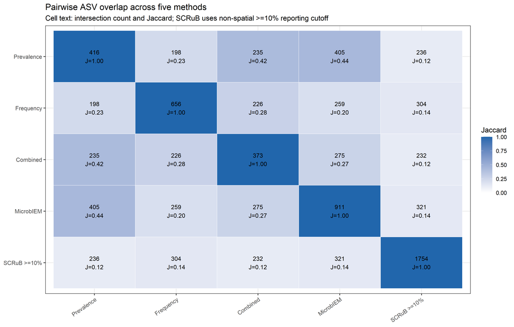

```r
method_levels <- c("Prevalence", "Frequency", "Combined", "MicrobIEM", "SCRuB >=10%")
p_overlap_matrix <- five_method_pairwise |>
  mutate(
    method_1 = factor(method_1, levels = method_levels),
    method_2 = factor(method_2, levels = rev(method_levels)),
    cell_label = paste0(overlap_ASVs, "\nJ=", sprintf("%.2f", jaccard))
  ) |>
  ggplot(aes(method_1, method_2, fill = jaccard)) +
  geom_tile(color = "white") +
  geom_text(aes(label = cell_label), size = 3.2) +
  scale_fill_gradient(low = "white", high = "#2166AC", limits = c(0, 1)) +
  labs(
    title = "Pairwise ASV overlap across five methods",
    subtitle = "Cell text: intersection count and Jaccard; SCRuB uses non-spatial >=10% reporting cutoff",
    x = NULL, y = NULL, fill = "Jaccard"
  ) +
  theme(axis.text.x = element_text(angle = 35, hjust = 1))

p_membership <- five_method_patterns |>
  slice_head(n = 15) |>
  mutate(membership = factor(membership, levels = rev(membership))) |>
  ggplot(aes(n_ASVs, membership)) +
  geom_col(fill = "#4C78A8") +
  geom_text(aes(label = n_ASVs), hjust = -0.15, size = 3.3) +
  labs(
    title = "Largest exact ASV membership patterns",
    subtitle = paste0(
      "P=prevalence, F=frequency, C=combined, M=MicrobIEM, S=SCRuB >=10%; ",
      "all-five intersection = ", five_way_shared_10
    ),
    x = "ASVs", y = NULL
  ) +
  coord_cartesian(xlim = c(0, max(five_method_patterns$n_ASVs) * 1.12))

print(p_overlap_matrix)
```

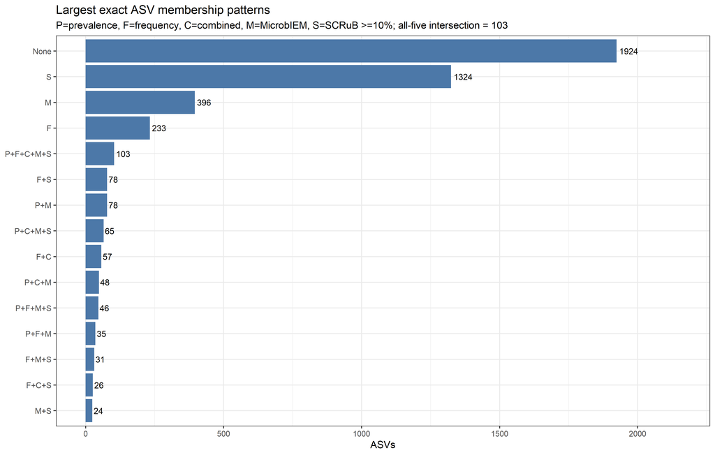

```r
print(p_membership)
```

```r
ggsave(file.path(output_dir, "06_12_five_method_overlap_matrix.png"),
       p_overlap_matrix, width = 10, height = 8, dpi = 300)
ggsave(file.path(output_dir, "06_13_five_method_membership_patterns.png"),
       p_membership, width = 10, height = 7, dpi = 300)
```

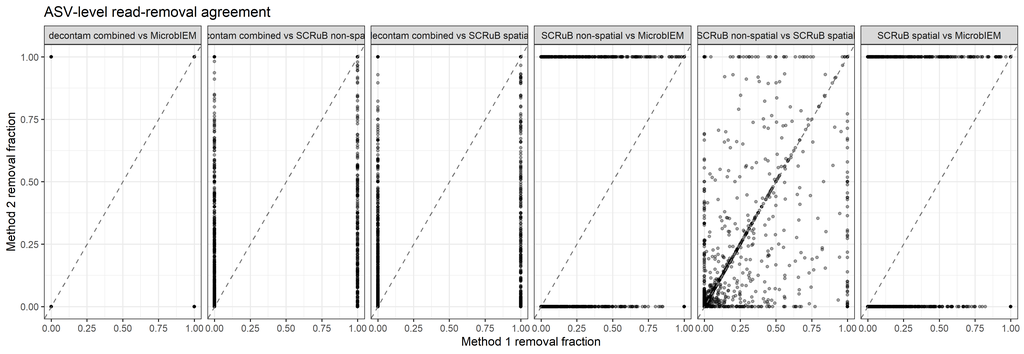

```r
scatter_data <- bind_rows(lapply(tool_pairs, function(pair) {
  data.frame(method_1 = pair[1], method_2 = pair[2],
             x = fraction_matrix[[pair[1]]], y = fraction_matrix[[pair[2]]])
})) |>
  mutate(panel = paste(method_1, "vs", method_2))

p_scatter <- ggplot(scatter_data, aes(x, y)) +
  geom_point(alpha = 0.35, size = 1) +
  geom_abline(slope = 1, intercept = 0, linetype = 2, color = "grey45") +
  facet_wrap(~panel, nrow = 1) +
  scale_x_continuous(limits = c(0, 1)) + scale_y_continuous(limits = c(0, 1)) +
  labs(title = "ASV-level read-removal agreement", x = "Method 1 removal fraction",
       y = "Method 2 removal fraction")
print(p_scatter)
```

```r
ggsave(file.path(output_dir, "06_04_pairwise_removal_scatter.png"), p_scatter,
       width = 13, height = 4.5, dpi = 300)
```

## 5.6 Shared and method-specific taxa

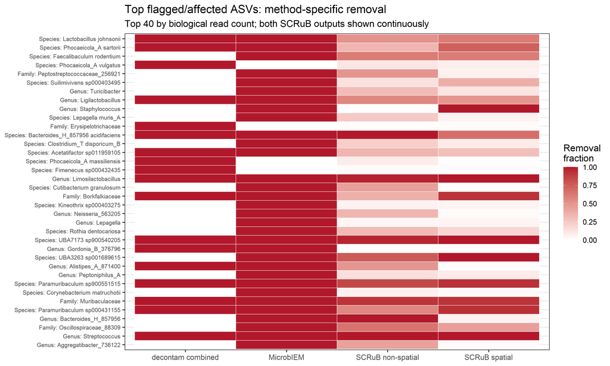

```r
taxon_label <- function(df) {
  rank_candidates <- c("Species", "Genus", "Family", "Order", "Class", "Phylum")
  available <- intersect(rank_candidates, names(df))
  out <- rep(NA_character_, nrow(df))
  for (rank_name in available) {
    value <- as.character(df[[rank_name]])
    use <- is.na(out) & !is.na(value) & nzchar(value)
    out[use] <- paste0(rank_name, ": ", value[use])
  }
  out[is.na(out)] <- df$ASV[is.na(out)]
  out
}

discordant_taxa <- feature_agreement |>
  mutate(
    taxon = taxon_label(feature_agreement),
    call_pattern = paste0(
      "D", as.integer(decontam_combined_call),
      "_SN", as.integer(SCRuB_nonspatial_ge_50pct),
      "_SS", as.integer(SCRuB_spatial_ge_50pct),
      "_M", as.integer(MicrobIEM_call)
    ),
    mean_removed_fraction = rowMeans(cbind(
      decontam_combined_removed_fraction, SCRuB_nonspatial_removed_fraction,
      SCRuB_spatial_removed_fraction,
      MicrobIEM_removed_fraction
    ))
  ) |>
  filter(decontam_combined_call | SCRuB_nonspatial_ge_50pct |
           SCRuB_spatial_ge_50pct | MicrobIEM_call) |>
  arrange(desc(original_biological_reads))
write_csv(discordant_taxa, file.path(output_dir, "06_11_flagged_taxa_and_call_patterns.csv"))

top_discordant <- discordant_taxa |>
  slice_head(n = 40) |>
  select(ASV, taxon, original_biological_reads,
         decontam_combined_removed_fraction,
         SCRuB_nonspatial_removed_fraction, SCRuB_spatial_removed_fraction,
         MicrobIEM_removed_fraction) |>
  pivot_longer(ends_with("removed_fraction"), names_to = "method", values_to = "removed_fraction") |>
  mutate(
    method = recode(method,
      decontam_combined_removed_fraction = "decontam combined",
      SCRuB_nonspatial_removed_fraction = "SCRuB non-spatial",
      SCRuB_spatial_removed_fraction = "SCRuB spatial",
      MicrobIEM_removed_fraction = "MicrobIEM"),
    taxon = factor(taxon, levels = rev(unique(taxon)))
  )

p_taxa <- ggplot(top_discordant, aes(method, taxon, fill = removed_fraction)) +
  geom_tile(color = "white") +
  scale_fill_gradient(low = "white", high = "#B2182B", limits = c(0, 1)) +
  labs(title = "Top flagged/affected ASVs: method-specific removal",
       subtitle = "Top 40 by biological read count; both SCRuB outputs shown continuously",
       x = NULL, y = NULL, fill = "Removal\nfraction") +
  theme(axis.text.y = element_text(size = 7))
print(p_taxa)
```

```r
ggsave(file.path(output_dir, "06_05_top_taxa_method_heatmap.png"), p_taxa,
       width = 10, height = 11, dpi = 300)
```

# 6 6. Sample-level impact

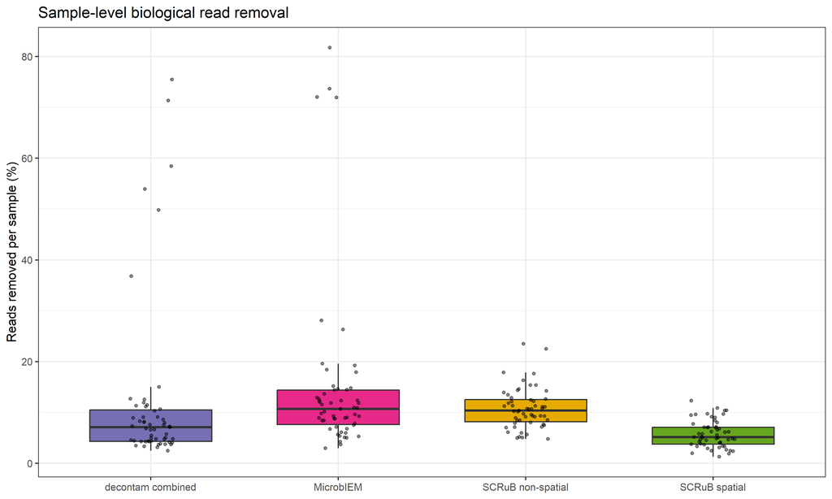

```r
sample_impact <- data.frame(
  sample_id = biological_ids,
  original_reads = rowSums(biological_counts),
  decontam_combined_removed_reads = as.numeric(combined_removed_samples[biological_ids]),
  SCRuB_nonspatial_removed_reads = as.numeric(scrub_removed_samples[biological_ids]),
  SCRuB_spatial_removed_reads = as.numeric(scrub_spatial_removed_samples[biological_ids]),
  MicrobIEM_removed_reads = as.numeric(microbiem_removed_samples[biological_ids])
) |>
  pivot_longer(ends_with("removed_reads"), names_to = "method", values_to = "removed_reads") |>
  mutate(
    removed_pct = 100 * removed_reads / original_reads,
    method = recode(method,
      decontam_combined_removed_reads = "decontam combined",
      SCRuB_nonspatial_removed_reads = "SCRuB non-spatial",
      SCRuB_spatial_removed_reads = "SCRuB spatial",
      MicrobIEM_removed_reads = "MicrobIEM")
  )
write_csv(sample_impact, file.path(output_dir, "06_12_sample_level_removal.csv"))

p_sample <- ggplot(sample_impact, aes(method, removed_pct, fill = method)) +
  geom_boxplot(outlier.shape = NA, width = 0.65) +
  geom_jitter(width = 0.12, alpha = 0.45, size = 1) +
  scale_fill_manual(values = c("#7570B3", "#E7298A", "#E6AB02", "#66A61E")) +
  labs(title = "Sample-level biological read removal", x = NULL,
       y = "Reads removed per sample (%)") + theme(legend.position = "none")
print(p_sample)
```

```r
ggsave(file.path(output_dir, "06_06_sample_level_removal.png"), p_sample,
       width = 8, height = 5, dpi = 300)
```

# 7 7. Verification and interpretation boundary

```r
monotonic_check <- threshold_summary |>
  arrange(method, batch_mode, threshold) |>
  group_by(method, batch_mode) |>
  summarise(non_decreasing = all(diff(contaminant_features) >= 0), .groups = "drop")

verification <- data.frame(
  check = c(
    "All six decontam runs completed",
    "All threshold grids are complete",
    "Contaminant counts are non-decreasing",
    "Cross-tool feature IDs are aligned",
    "Both SCRuB outputs contain every biological sample",
    "Spatial and non-spatial SCRuB used identical sample IDs",
    "Spatial SCRuB received complete unique wells",
    "MicrobIEM sensitivity grid is complete",
    "MicrobIEM calls decrease monotonically with stricter thresholds",
    "Non-spatial SCRuB reporting grid is complete",
    "Non-spatial SCRuB calls decrease with stricter cutoffs",
    "Common-scale five-method table is complete",
    "Five-way overlap is non-zero at SCRuB 10% and 50% cutoffs",
    "No positive control entered contaminant learning"
  ),
  passed = c(
    length(decontam_runs) == 6,
    nrow(threshold_summary) == 6 * length(thresholds),
    all(monotonic_check$non_decreasing),
    nrow(feature_agreement) == ncol(biological_counts),
    setequal(rownames(scrub_clean), biological_ids) &
      setequal(rownames(scrub_spatial_clean), biological_ids),
    setequal(rownames(scrub_clean), rownames(scrub_spatial_clean)),
    !anyNA(scrub_meta_spatial$well) & !anyDuplicated(scrub_meta_spatial$well),
    nrow(microbiem_sensitivity) ==
      length(microbiem_ratio_thresholds) * length(microbiem_span_thresholds),
    {
      ratio_check <- microbiem_sensitivity |>
        arrange(span_label, ratio_threshold) |>
        group_by(span_label) |>
        summarise(ok = all(diff(n_flagged_ASVs) <= 0), .groups = "drop")
      span_check <- microbiem_sensitivity |>
        mutate(span_order = match(as.character(span_label),
          c("Any detected", "0.25", "0.5", "0.75", "1"))) |>
        arrange(ratio_threshold, span_order) |>
        group_by(ratio_threshold) |>
        summarise(ok = all(diff(n_flagged_ASVs) <= 0), .groups = "drop")
      all(ratio_check$ok) & all(span_check$ok)
    },
    nrow(scrub_nonspatial_sensitivity) == length(scrub_nonspatial_thresholds),
    all(diff(scrub_nonspatial_sensitivity$n_affected_ASVs) <= 0),
    nrow(common_scale_sensitivity) ==
      3 * length(thresholds) + length(microbiem_ratio_thresholds) +
      length(scrub_nonspatial_thresholds),
    five_way_shared_10 > 0 & five_way_shared_50 > 0,
    !any(scope_info$is_positive_control)
  )
)
write_csv(verification, file.path(output_dir, "06_13_verification.csv"))
knitr::kable(verification)
```

| check | passed |
| --- | --- |
| All six decontam runs completed | TRUE |
| All threshold grids are complete | TRUE |
| Contaminant counts are non-decreasing | TRUE |
| Cross-tool feature IDs are aligned | TRUE |
| Both SCRuB outputs contain every biological sample | TRUE |
| Spatial and non-spatial SCRuB used identical sample IDs | TRUE |
| Spatial SCRuB received complete unique wells | TRUE |
| MicrobIEM sensitivity grid is complete | TRUE |
| MicrobIEM calls decrease monotonically with stricter thresholds | TRUE |
| Non-spatial SCRuB reporting grid is complete | TRUE |
| Non-spatial SCRuB calls decrease with stricter cutoffs | TRUE |
| Common-scale five-method table is complete | TRUE |
| Five-way overlap is non-zero at SCRuB 10% and 50% cutoffs | TRUE |
| No positive control entered contaminant learning | TRUE |

```r
if (!all(verification$passed)) stop("One or more verification checks failed.")
```

The output quantifies agreement; it does not establish which method is true. Differences are expected because decontam combined integrates frequency and prevalence evidence into a global binary call, MicrobIEM compares mean relative abundance between samples and two control classes, and SCRuB estimates sample-specific contamination fractions. The fixed 0.5 and ratio-1 settings must therefore be described as prespecified comparison settings, not as an empirically optimized winner.